# R-3

Introductory Regression Analyses

Importing 2018 PUMS data:

```r
Sys.setenv(CENSUS_KEY="601675c683d8379131e78a304b3e5f7d209edca3")

pums_vars_2018 <-
  pums_variables %>%
  filter(year == 2018, survey == "acs5")

pums_vars_2018_distinct_hh <-
  pums_vars_2018 %>%
  distinct(var_code, var_label, data_type, level) %>%
  filter(level == "housing")
```

```r
ca_counties <- counties("CA", cb = T, progress_bar = F)
bay_county_names <-
  c(
    "Alameda",
    "Contra Costa",
    "Marin",
    "Napa",
    "San Francisco",
    "San Mateo",
    "Santa Clara",
    "Solano",
    "Sonoma"
  )
bay_counties <-
  ca_counties %>%
  filter(NAME %in% bay_county_names)
```

1. Regression Analysis of the following variables by household: educational attainment (SCHL), household language (HHL), and commute time (JWMNP).

This analysis looks at the percent of non-english speaking homes, percent of homes without a higher degree (Associate’s and above), and percent of home with commute times greater than, or equal to, 15 minutes–all from PUMS data.

```r
bay_pums_analysis <-
  bay_pums %>%
  filter(!duplicated(SERIALNO),
         SPORDER == 1) %>%
  mutate(
    perc_nonenglish_homes = ifelse(
      (HHL_label != "English only"),
      WGTP,
      0),
    perc_without_higher_degree = ifelse(SCHL %in% 1:19 ,WGTP, 0),
    perc_commute_time = ifelse(JWMNP>=15, WGTP, 0)
    ) %>%
  group_by(PUMA) %>%
  summarize(
    perc_nonenglish_homes = sum(perc_nonenglish_homes, na.rm =T)/sum(WGTP, na.rm = T)*100,
    perc_without_higher_degree = sum(perc_without_higher_degree, na.rm =T)/sum(WGTP, na.rm = T)*100,
    perc_commute_time = sum(perc_commute_time, na.rm =T)/sum(WGTP, na.rm = T)*100
  ) %>% filter(
    !is.na(perc_without_higher_degree),
    !is.na(perc_nonenglish_homes),
    !is.na(perc_commute_time),
    perc_nonenglish_homes != 0,
    perc_without_higher_degree != 0,
    perc_commute_time !=0
  )
```

This regression analysis results in a positive correlation between the percent of non-english speaking households and commute time (>15 min). Additionally, it yields a slight negative correlation between commute time and the percent of households with a lack of a higher degree. Finally, it yields a slight positive correlation between the percent of non-english speaking households and the percent of households with a lack of a higher degree.

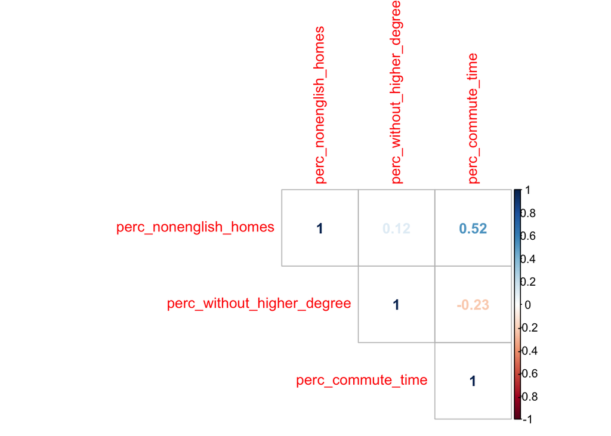

```r
bay_pums_analysis$PUMA <- NULL
bay_pums_analysis$perc_without_higher_degree <- as.numeric(bay_pums_analysis$perc_without_higher_degree)

correlationplot <- bay_pums_analysis %>%
  select(
    perc_nonenglish_homes,
    perc_without_higher_degree,
    perc_commute_time
  ) %>%
  cor()

corrplot(
  correlationplot,
  method = "number",
  type = "upper"
)
```

Plots demonstrating the relationships between language and education, language and commute time, and education and commute time.

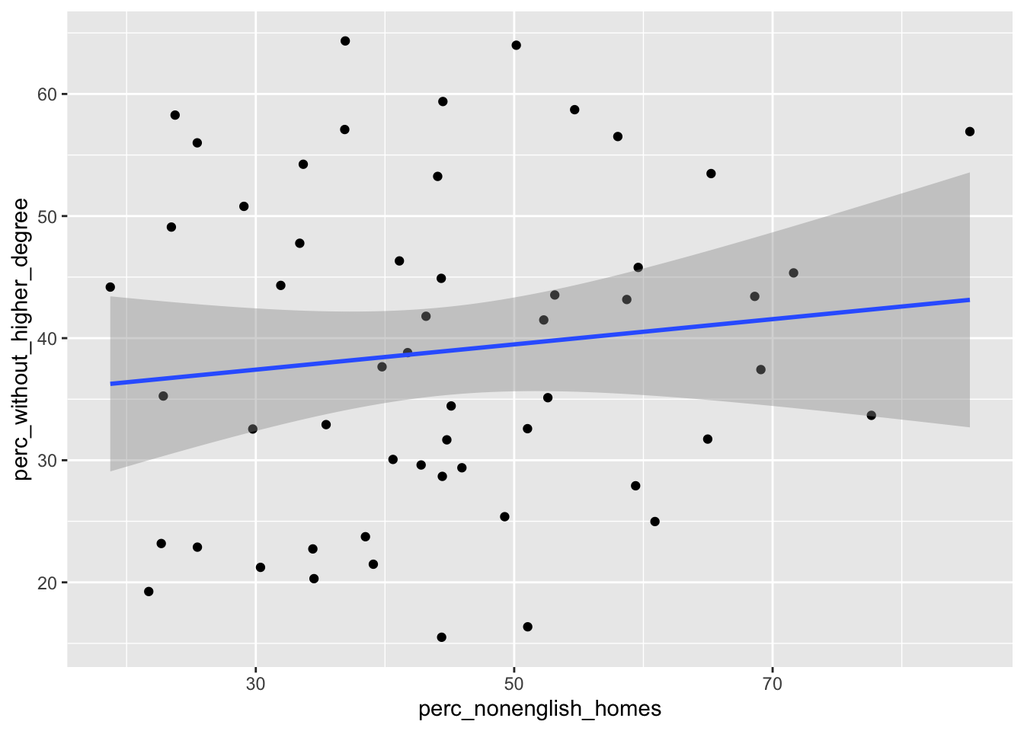

```r
ggplot(
  data = bay_pums_analysis,
  aes(
      x = perc_nonenglish_homes,
      y = perc_without_higher_degree
    )
) +
  geom_point() +
  geom_smooth(method = "lm")
```

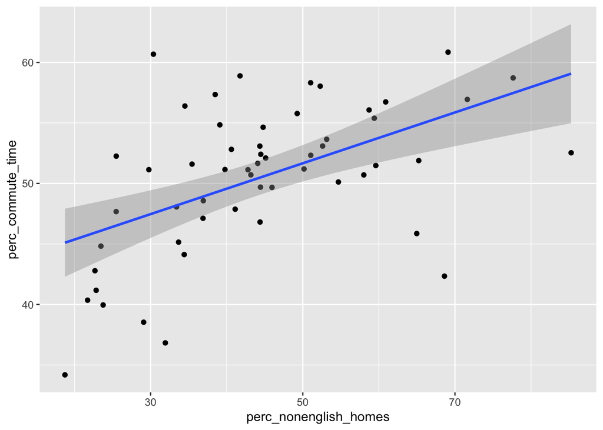

```r
ggplot(
  data = bay_pums_analysis,
  aes(
      x = perc_nonenglish_homes,
      y = perc_commute_time
    )
) +
  geom_point() +
  geom_smooth(method = "lm")
```

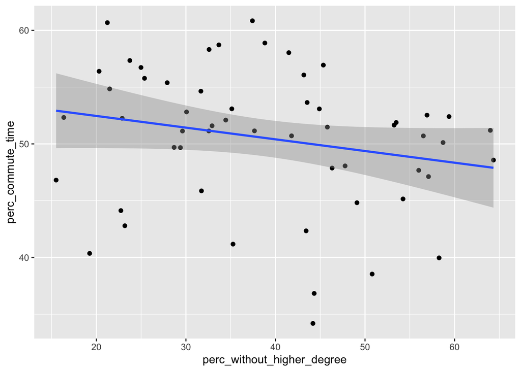

```r
ggplot(
  data = bay_pums_analysis,
  aes(
      x = perc_without_higher_degree,
      y = perc_commute_time
    )
) +
  geom_point() +
  geom_smooth(method = "lm")
```

The slightly positive correlation between non-english speaking homes and homes without a higher degree is not statistically significant.

However, the positive correlation between non-english speaking homes and commute time is statistically significant (p<.05).

There is a slightly negative correlation between a lack of higher degree and commute time, although it has a p-value <0.1.

Finally, a multiple regression with commute time as the dependent variable, and degree and language as the independents, yields statistically significant results. Lack of a higher degree has a slightly negative correlation with commute time (p<0.05). Non-english speaking homes have a positive correlation (p=7.53e-06).

This may suggest that homes that do not speak english have higher commute times than those that do. While the p-values suggest that a lack of a higher degree might result in less of a commute time, there are significant confounding factors and issues with the construction of the datasets used in this analysis that preclude any sort of causal interpretations.

I chose a lack of higher degrees as a proxy for service jobs; the latter would yield more insight into commute times, as service jobs tend to pay lower wages and are often occupied by people who cannot afford to live in the area they’re working (Urban Habitat, NHP). However, there are many other types of occupations at play in this data section. Also, this is looking at household data for educational attainment, and there may be vast differences within households regarding commute time and educational attainment.

Non-english speaking household comprise a large population with varying disparities. I chose this section based on my knowledge of service workers on Stanford campus, who tend to speak Spanish and/or Tagalog, among other languages. By accounting for educational attainment, I attempted to exclude non-English speaking immigrant populations with higher educational attainment, which might complicate commute time, or commuting decisions might be made for reasons other than affordability. Furthermore, by looking at non-english speaking homes, I am not looking at other populations that may have to commute long distances for issues of affordability, like Black American communities, and other english-speaking populations affected by the Bay Area’s affordability crisis.

```r
model <- lm(perc_without_higher_degree ~ perc_nonenglish_homes, bay_pums_analysis)

summary(model)
```

```
##
## Call:
## lm(formula = perc_without_higher_degree ~ perc_nonenglish_homes,
##     data = bay_pums_analysis)
##
## Residuals:
##      Min       1Q   Median       3Q      Max
## -23.4052  -9.9595  -0.7777  11.1778  26.2071
##
## Coefficients:
##                       Estimate Std. Error t value Pr(>|t|)
## (Intercept)            34.3172     5.6310   6.094 1.28e-07 ***
## perc_nonenglish_homes   0.1034     0.1199   0.863    0.392
## ---
## Signif. codes:  0 '***' 0.001 '**' 0.01 '*' 0.05 '.' 0.1 ' ' 1
##
## Residual standard error: 13.34 on 53 degrees of freedom
## Multiple R-squared:  0.01385,    Adjusted R-squared:  -0.004755
## F-statistic: 0.7444 on 1 and 53 DF,  p-value: 0.3921
```

```r
model <- lm(perc_commute_time ~ perc_nonenglish_homes, bay_pums_analysis)

summary(model)
```

```
##
## Call:
## lm(formula = perc_commute_time ~ perc_nonenglish_homes, data = bay_pums_analysis)
##
## Residuals:
##      Min       1Q   Median       3Q      Max
## -13.2339  -2.8111   0.7351   2.8830  13.1351
##
## Coefficients:
##                       Estimate Std. Error t value Pr(>|t|)
## (Intercept)           41.16874    2.20840  18.642  < 2e-16 ***
## perc_nonenglish_homes  0.20994    0.04701   4.466 4.22e-05 ***
## ---
## Signif. codes:  0 '***' 0.001 '**' 0.01 '*' 0.05 '.' 0.1 ' ' 1
##
## Residual standard error: 5.232 on 53 degrees of freedom
## Multiple R-squared:  0.2734, Adjusted R-squared:  0.2597
## F-statistic: 19.94 on 1 and 53 DF,  p-value: 4.216e-05
```

```r
model <- lm(perc_commute_time ~ perc_without_higher_degree, bay_pums_analysis)

summary(model)
```

```
##
## Call:
## lm(formula = perc_commute_time ~ perc_without_higher_degree,
##     data = bay_pums_analysis)
##
## Residuals:
##     Min      1Q  Median      3Q     Max
## -15.784  -1.876   1.125   3.805  10.177
##
## Coefficients:
##                            Estimate Std. Error t value Pr(>|t|)
## (Intercept)                54.52111    2.51273  21.698   <2e-16 ***
## perc_without_higher_degree -0.10296    0.06114  -1.684   0.0981 .
## ---
## Signif. codes:  0 '***' 0.001 '**' 0.01 '*' 0.05 '.' 0.1 ' ' 1
##
## Residual standard error: 5.98 on 53 degrees of freedom
## Multiple R-squared:  0.05079,    Adjusted R-squared:  0.03288
## F-statistic: 2.836 on 1 and 53 DF,  p-value: 0.09808
```

```r
model <- lm(perc_commute_time ~ perc_without_higher_degree + perc_nonenglish_homes, bay_pums_analysis)

summary(model)
```

```
##
## Call:
## lm(formula = perc_commute_time ~ perc_without_higher_degree +
##     perc_nonenglish_homes, data = bay_pums_analysis)
##
## Residuals:
##      Min       1Q   Median       3Q      Max
## -12.9672  -2.2972   0.7284   3.1213  10.9775
##
## Coefficients:
##                            Estimate Std. Error t value Pr(>|t|)
## (Intercept)                45.73021    2.73554  16.717  < 2e-16 ***
## perc_without_higher_degree -0.13292    0.05117  -2.598   0.0122 *
## perc_nonenglish_homes       0.22368    0.04497   4.975 7.53e-06 ***
## ---
## Signif. codes:  0 '***' 0.001 '**' 0.01 '*' 0.05 '.' 0.1 ' ' 1
##
## Residual standard error: 4.97 on 52 degrees of freedom
## Multiple R-squared:  0.3569, Adjusted R-squared:  0.3321
## F-statistic: 14.43 on 2 and 52 DF,  p-value: 1.038e-05
```

2. Second multiple regression analysis of the following variables: PM2.5 concentration, the percent of non-white households, and percent of households making under $100k.

```r
bay_county_names <-
  c(
    "Alameda",
    "Contra Costa",
    "Marin",
    "Napa",
    "San Francisco",
    "San Mateo",
    "Santa Clara",
    "Solano",
    "Sonoma"
  )

ca_tracts <- tracts("CA", cb = T, progress_bar = F)

ces3_bay_pm25 <-
  ces3 %>%
  filter(`California County` %in% bay_county_names) %>%
  select(`Census Tract`, PM2.5) %>%
  left_join(
    ca_tracts %>%
      transmute(GEOID = as.numeric(GEOID)),
    by = c("Census Tract" = "GEOID")
  ) %>%
  st_as_sf()
```

```r
bay_multiple_tract <-
  getCensus(
    name = "acs/acs5",
    vintage = 2018,
    region = "tract:*",
    regionin = "state:06+county:001,013,041,055,075,081,085,095,097",
    vars = c(
      "B19001A_001E",
      "B19001_001E",
      "B19001_014E",
      "B19001_015E",
      "B19001_016E",
      "B19001_017E",
      "B15003_001E",
      "B15003_021E",
      "B15003_022E",
      "B15003_023E",
      "B15003_024E",
      "B15003_025E"
    )
  ) %>%
  transmute(
    tract = paste0(state, county, tract) %>% as.numeric(),
    perc_nonwhite = (1 - (B19001A_001E / B19001_001E)),
    perc_under100k = (1 - ((B19001_014E + B19001_015E + B19001_016E + B19001_017E) / B19001_001E)),
  ) %>%
  filter(
    !is.na(perc_nonwhite),
    !is.na(perc_under100k)
  )
```

```r
bay_pm25_race_income <-
  bay_multiple_tract %>%
  left_join(
    ces3_bay_pm25 %>%
      st_set_geometry(NULL),
    by = c("tract" = "Census Tract"))
```

With a high degree of statistical significance (p=2e-16 in both cases), there is a positive correlation between the percent of non-white homes in a Census tract and the concentration of PM2.5. When running a multiple regression that includes the percent of homes with an income under $100k (derived from article about what constitutes low-income in Bay Area), there is a negative correlation between those homes and PM2.5 concentrations.

Due to the history of redlining, which created Black and other poc dominant communities with reduced home-values, pollution sites tended to be situated near these communities, resulting in various disproportionate environmental harms ( Bullard). Studies have shown that a key indicator of pollution site placement is race (particularly Black and Indigenous people), even when accounting for income (Bullard). This may explain why there is a positive correlation here, but the category of non-white is too broad and must be disaggregated to get a clearer sense of which racial groups are most impacted–which may lead to stronger correlations.

As for the negative correlation between the income category and PM2.5, that is a puzzling result. As I mentioned earlier, race is a stronger predictor of pollution than income in the US based on past studies, but it is unclear to me what that looks like in the Bay Area. Perhaps the histories and realities of rapid displacement of people of color, particularly Black people, from the Bay Area, caused by pricing out, or gentrification, may be at play.

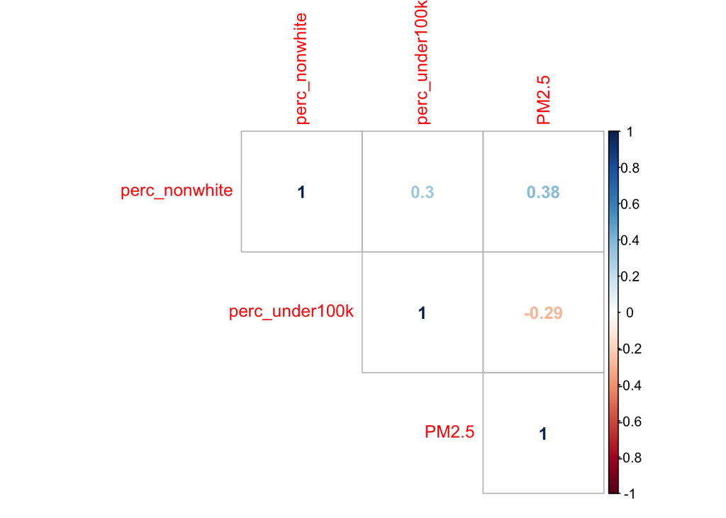

```r
correlationplot <- bay_pm25_race_income %>%
  select(
    perc_nonwhite,
    perc_under100k,
    PM2.5
  ) %>%
  cor()

corrplot(
  correlationplot,
  method = "number",
  type = "upper"
)
```

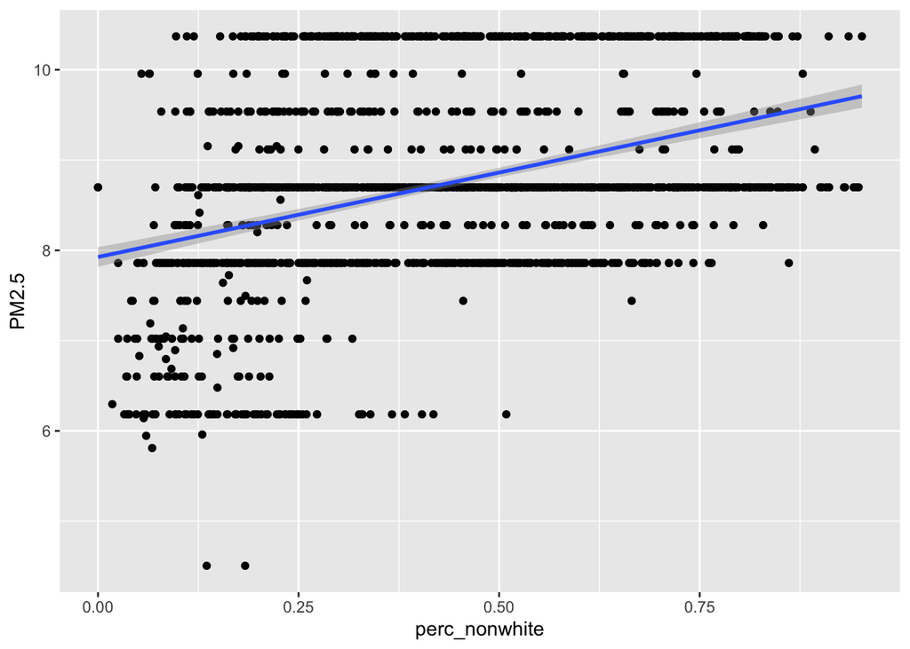

```r
ggplot(
  data = bay_pm25_race_income,
  aes(
      x = perc_nonwhite,
      y = PM2.5
    )
) +
  geom_point() +
  geom_smooth(method = "lm")
```

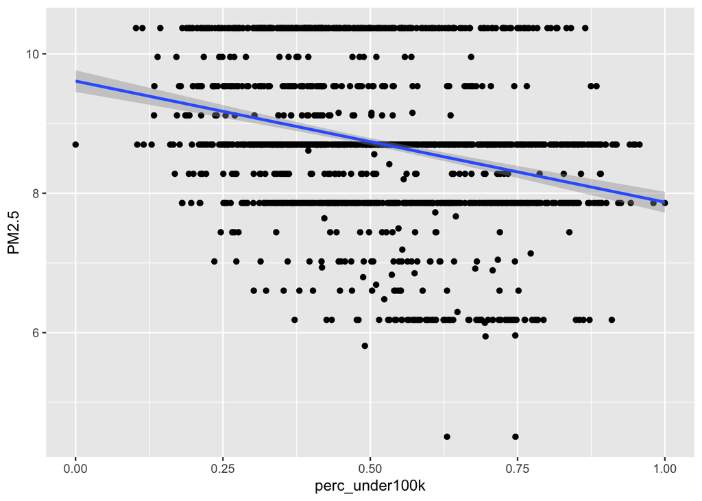

```r
ggplot(
  data = bay_pm25_race_income,
  aes(
      x = perc_under100k,
      y = PM2.5
    )
) +
  geom_point() +
  geom_smooth(method = "lm")
```

```r
model <- lm(PM2.5 ~ perc_nonwhite, bay_pm25_race_income)

summary(model)
```

```
##
## Call:
## lm(formula = PM2.5 ~ perc_nonwhite, data = bay_pm25_race_income)
##
## Residuals:
##     Min      1Q  Median      3Q     Max
## -3.7629 -0.6882 -0.1359  0.7730  2.2621
##
## Coefficients:
##               Estimate Std. Error t value Pr(>|t|)
## (Intercept)    7.92594    0.05537  143.15   <2e-16 ***
## perc_nonwhite  1.87102    0.11497   16.27   <2e-16 ***
## ---
## Signif. codes:  0 '***' 0.001 '**' 0.01 '*' 0.05 '.' 0.1 ' ' 1
##
## Residual standard error: 1.022 on 1575 degrees of freedom
## Multiple R-squared:  0.1439, Adjusted R-squared:  0.1434
## F-statistic: 264.8 on 1 and 1575 DF,  p-value: < 2.2e-16
```

```r
model <- lm(PM2.5 ~ perc_under100k + perc_nonwhite, bay_pm25_race_income)

summary(model)
```

```
##
## Call:
## lm(formula = PM2.5 ~ perc_under100k + perc_nonwhite, data = bay_pm25_race_income)
##
## Residuals:
##      Min       1Q   Median       3Q      Max
## -3.15531 -0.58064 -0.06683  0.52687  2.39700
##
## Coefficients:
##                Estimate Std. Error t value Pr(>|t|)
## (Intercept)     9.01156    0.07266  124.03   <2e-16 ***
## perc_under100k -2.68734    0.13214  -20.34   <2e-16 ***
## perc_nonwhite   2.53653    0.10745   23.61   <2e-16 ***
## ---
## Signif. codes:  0 '***' 0.001 '**' 0.01 '*' 0.05 '.' 0.1 ' ' 1
##
## Residual standard error: 0.91 on 1574 degrees of freedom
## Multiple R-squared:  0.3221, Adjusted R-squared:  0.3212
## F-statistic: 373.9 on 2 and 1574 DF,  p-value: < 2.2e-16
```

Works Cited:

(Bullard, Robert, Ph.D). “Time for whites to stop dumping their pollution on people of color.” "https://drrobertbullard.com/time-for-whites-to-stop-dumping-their-pollution-on-people-of-color/

(Urban Habitat). “Race, Inequality, and the Resegregation of the Bay Area.” https://urbanhabitat.org/sites/default/files/UH%20Policy%20Brief2016.pdf

(NPH). “Moving Silicon Valley Forward: Housing, Transit, & Traffic at a Crossroad.” https://www.reimaginerpe.org/files/MovingSiliconValleyForward1.pdf